# Bulk RNA-seq TCGA-GBM Downstream Analysis: Proneural vs Mesenchymal GBM Subtypes

[figure not shown]

**End-to-end bulk RNA-seq downstream analysis pipeline** applied to the **TCGA Glioblastoma Multiforme (GBM) dataset**, focusing on **Proneural (PN) vs Mesenchymal (ME) transcriptional subtypes**.

Covers:

- Quality Control (QC)
- Exploratory Data Analysis (EDA)
- Differential Expression (DE) Analysis
- Pathway Enrichment
- Cellular Deconvolution, and
- Multivariate Survival Analysis (Cox Proportional Hazards Model),

demonstrating the **complete computational biology workflow for bulk RNA-seq tumor subtype analysis**.

## Key Results

| Analysis | Finding |
| --- | --- |
| **Samples (post-QC)** | 180 primary GBM tumors • 55 PN • 125 ME |
| **DE genes (ME vs PN)** | 2,658 significant genes • 1,528 up in ME, 1,130 up in PN • >94% DESeq2/EdgeR consensus |
| **ME upregulated theme** | Mesenchymal/wound-healing program • Immune infiltration, cytokine signaling, ECM remodeling |
| **PN upregulated theme** | Neural identity • Axonogenesis, synapse assembly Cell cycle proliferation • Chromosome segregation, nuclear division |
| **Dominant ME cell types** | MES-like neoplastic cells, TAMs, Microglia, T/B/NK cells, Endothelial, Mural cells |
| **Dominant PN cell types** | NPC/OPC-like neoplastic cells, Neurons, Oligodendrocytes, Radial glia |
| **Survival (KM)** | Significant PN vs ME difference • Log-rank `p=0.033` |
| **Survival (Cox)** | **Age at diagnosis dominant death predictor** • Hazard Ratio (HR) = 1.045/year (`p=1.08e-07`) **Subtype NOT a significant predictor** • Hazard Ratio (HR) = 1.079 (`p=0.831`) |

## Repository Structure

```
Bulk-RNAseq-TCGA-GBM/
├── 01_data/
│   ├── 01_raw/                    # Downloaded TCGA-GBM data (generated by pipeline)
│   └── 02_processed/              # Intermediate RDS files (generated by pipeline)
├── 02_notebooks/
│   ├── 00_setup_project_env.qmd
│   ├── 01_download_raw_data.qmd
│   ├── 02_prepare_dataset.qmd
│   ├── 03_perform_qc.qmd
│   ├── 04_perform_eda.qmd
│   ├── 05_perform_de_analysis.qmd
│   ├── 06_perform_pathway_enrichment.qmd
│   ├── 07_perform_deconvolution.qmd
│   ├── 08_integrate_and_interpret_findings.qmd
│   └── 09_summarize_project.qmd
├── 03_figures/                    # All plots generated by pipeline
├── 04_results/                    # All results CSVs and RDS files generated by pipeline
│
├── .gitignore
└── README.md
```

## Dataset

**TCGA-GBM**: The Cancer Genome Atlas Glioblastoma Multiforme cohort

- **Downloaded programmatically** via `TCGAbiolinks`
- **Bulk RNA-seq** data
- **Expression data:** Unstranded raw counts matrix, primary tumor samples only
- **Clinical data:** Patient survival, age at diagnosis, and paper-curated subtype labels (Verhaak et al. 2010)
- **Post-QC dataset:** 180 samples × 16,164 protein-coding genes (55 PN, 125 ME)

## Installation

### Prerequisites

- **R** 4.5.3+
- **RStudio** (recommended) or any R environment
- **Quarto** for rendering notebooks

### Key R Packages

| Package | Version | Purpose |
| --- | --- | --- |
| `TCGAbiolinks` | 2.38.0 | TCGA data download and preparation |
| `DESeq2` | 1.50.2 | Primary differential expression analysis |
| `edgeR` | 4.8.2 | Confirmatory differential expression analysis |
| `clusterProfiler` | 4.18.4 | ORA and GSEA pathway enrichment |
| `GSVA` | 2.4.4 | Per-sample pathway activity scoring |
| `MCPcounter` | 1.2.0 | Cell type deconvolution |
| `survival` + `survminer` | 3.8.6 + 0.5.2 | Survival analysis and visualization |
| `tidyverse` | 2.0.0 | Data manipulation and visualization |
| `broom` | 1.0.13 | Tidy model outputs into clean dataframes |

### Tested On

- **CPU:** 16 logical cores (Intel Core i7-13620H, 13th Gen)
- **RAM:** 7.6 GB available (WSL2 allocation; host machine has 16 GB)
- **OS:** Windows 11 with WSL2 (Ubuntu)
- **GPU:** NVIDIA RTX 4050 (not used in this project)

### Setup

1. **Clone the repository**

```bash
git clone https://github.com/Shirshak52/Bulk-RNAseq-TCGA-GBM.git
cd Bulk-RNAseq-TCGA-GBM
```

2. **Create the conda environment**

```bash
conda env create -f environment.yml
conda activate gbm_project_env
```

## Usage

Execute notebooks sequentially (00 → 09). Each notebook saves intermediate outputs consumed by the next. Click any notebook name to view its rendered HTML report.

| Notebook | Description |
| --- | --- |
| [`00_setup_project_env.qmd`](https://shirshak52.github.io/Bulk-RNAseq-TCGA-GBM/02_notebooks/00_setup_project_env.html) | Project directory setup, package verification |
| [`01_download_raw_data.qmd`](https://shirshak52.github.io/Bulk-RNAseq-TCGA-GBM/02_notebooks/01_download_raw_data.html) | TCGA-GBM counts matrix and clinical metadata download |
| [`02_prepare_dataset.qmd`](https://shirshak52.github.io/Bulk-RNAseq-TCGA-GBM/02_notebooks/02_prepare_dataset.html) | SummarizedExperiment preparation, counts/metadata extraction |
| [`03_perform_qc.qmd`](https://shirshak52.github.io/Bulk-RNAseq-TCGA-GBM/02_notebooks/03_perform_qc.html) | Subtype/gene filtering, low-expression and outlier removal |
| [`04_perform_eda.qmd`](https://shirshak52.github.io/Bulk-RNAseq-TCGA-GBM/02_notebooks/04_perform_eda.html) | PCA, scree plot, PC-level pathway enrichment |
| [`05_perform_de_analysis.qmd`](https://shirshak52.github.io/Bulk-RNAseq-TCGA-GBM/02_notebooks/05_perform_de_analysis.html) | DESeq2 + EdgeR DE analysis, volcano plots, consensus gene lists |
| [`06_perform_pathway_enrichment.qmd`](https://shirshak52.github.io/Bulk-RNAseq-TCGA-GBM/02_notebooks/06_perform_pathway_enrichment.html) | ORA + GSEA against GO:BP and KEGG databases |
| [`07_perform_deconvolution.qmd`](https://shirshak52.github.io/Bulk-RNAseq-TCGA-GBM/02_notebooks/07_perform_deconvolution.html) | MCPcounter deconvolution with GBM-specific marker sets |
| [`08_integrate_and_interpret_findings.qmd`](https://shirshak52.github.io/Bulk-RNAseq-TCGA-GBM/02_notebooks/08_integrate_and_interpret_findings.html) | GSVA, correlation heatmap, KM + Cox survival analysis |
| [`09_summarize_project.qmd`](https://shirshak52.github.io/Bulk-RNAseq-TCGA-GBM/02_notebooks/09_summarize_project.html) | End-to-end project summary with all figures |

## Method Overview

### Project Pipeline Architecture

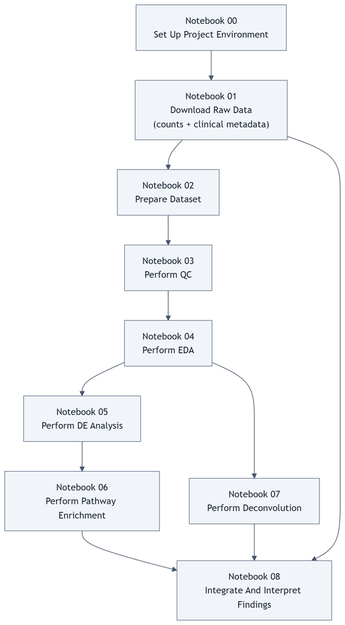

Project Pipeline Overview

### Analytical Decisions

- **Subtype focus**: Restricted to **Proneural (PN) and Mesenchymal (ME) subtypes**, the two **most biologically distinct and clinically relevant** GBM subtypes per Verhaak et al. (2010)
- **DE consensus**: **Intersection of DESeq2 and EdgeR results (>94% overlap)** used as the **primary gene list**, ensuring findings are robust to method choice
- **Pathway databases**: **GO:BP** and **KEGG** used throughout, consistent across EDA, pathway enrichment, and GSVA
- **Deconvolution marker gene sets**:
  - **Primary set**:
    - GBM-specific **neoplastic state markers**: Neftel (2019)
    - **Immune/stromal markers**: Moreno (2023)
  - **Confirmatory set**:
    - GBM-specific **neoplastic state markers**: Moreno (2023)
    - **Immune/stromal markers**: Moreno (2023)

  chosen to reflect the **single-cell-informed understanding of GBM cellular composition.**
- **Cox variable selection**: Hybrid of:
  - **Literature-informed** inclusion (for subtype, age)
  - **Data-driven greedy forward selection** with **pairwise correlation thresholds**, for:
    - **GSVA pathways**: max rho < 0.8, min informativeness > 0.15
    - **Deconvolution cell types**: max rho < 0.7, min informativeness > 0.3

## Key Findings

### Differential Expression

- 1,528 genes **upregulated in ME**
- 1,130 genes **upregulated in PN**
- `padj < 0.05`, `|log2FC| > 1`
- **confirmed independently** by DESeq2 and EdgeR with **>94% consensus**

### Pathway Enrichment

- **ME upregulated**: **Mesenchymal/wound-healing** program
  - Leukocyte migration, cytokine signaling, ECM remodeling, adaptive immunity
  - Reflects a **permanently active wound-healing-like state** consistent with the **“wound that never heals” phenomenon** in cancer biology
- **PN upregulated:**
  - **ORA**: **Neural identity** program
    - Axonogenesis, synapse assembly, CNS neuron differentiation
  - **GSEA**: **Cell cycle/proliferation** program
    - Chromosome segregation, nuclear division, DNA damage response

### Deconvolution

- **ME tumors:** Enriched for **MES-like neoplastic cells** and **broad immune/stromal infiltrate** (TAMs, Microglia, T/B/NK cells, Endothelial, Mural cells)
- **PN tumors:** Enriched for **NPC/OPC-like neoplastic cells** and **neural cell types** (Neurons, Oligodendrocytes, Radial glia)
- Both primary (Neftel + Moreno) and confirmatory (Moreno + Moreno) marker sets produced consistent results

### Integration & Survival

- **Myeloid lineage cells** (TAM, Microglia, Monocytes, DC) specifically **drive the ME immune/wound-healing pathway signal**
  - Confirmed by **per-sample GSVA-deconvolution correlation within both subtypes**
- **Subtype survival difference** (KM log-rank `p=0.033`) **disappears in multivariate Cox model** (subtype HR=1.079, `p=0.831`)
  - The **effect is mediated through biological variables**, particularly **age (HR=1.045/year, `p=1.08e-07`)** and **immune pathway activity (HR=2.879, `p=0.074`, trending)**
- **Proportional hazards assumption verified** (global Schoenfeld `p=0.210`)

## Reproducibility

**Expected runtime:** **~45 minutes to 1 hour for the complete pipeline** (Notebooks 00–09), run sequentially **on the tested hardware specifications above**.

**Note:** `01_download_raw_data.qmd` and `02_prepare_dataset.qmd` require an **active internet connection** and **GDC portal access**. **All subsequent notebooks run entirely offline** from saved intermediate files.

## Data Sources, Tools, and References

- **Primary dataset and patient metadata:** TCGA-GBM via GDC portal, accessed through `TCGAbiolinks`
- **GBM Subtype Framework:** [*Integrated Genomic Analysis Identifies Clinically Relevant Subtypes of Glioblastoma Characterized by Abnormalities in PDGFRA, IDH1, EGFR, and NF1*](https://www.doi.org/10.1016/j.ccr.2009.12.020) (Verhaak et al., 2010)
- **Single-cell GBM States:** [*An Integrative Model of Cellular States, Plasticity, and Genetics for Glioblastoma*](https://doi.org/10.1016/j.cell.2019.06.024) (Neftel et al., 2019)
- **Deconvolution Marker Gene Sets:** [GBMDeconvoluteR GitHub](https://github.com/GliomaGenomics/GBMDeconvoluteR/tree/main)
- **Key Analysis Tools:** `TCGAbiolinks`, `DESeq2`, `edgeR`, `clusterProfiler`, `GSVA`, `MCPcounter`, `survival`, `survminer`
- **Pathway Databases:** GO:BP (Gene Ontology Consortium), KEGG (Kyoto University)

## Contact

- **Author:** Shirshak Aryal
- **Email:** shirshak.acad@gmail.com

## License

This project is licensed under the MIT License — see LICENSE file for details.